# Lab 2: Avocado Prices

**GitHub Repository**: https://github.com/lilysteinberg/GSB-544---Computing-and-ML/tree/main/Week%202

# Data Set-up

::: {#cell-Data Set-up .cell execution_count=1}

```python
# packages
import pandas as pd
from plotnine import *

# data
avo = pd.read_csv("C:/Users/lilyg/OneDrive/Documents/MSBA/GSB 544 - Computing and ML/Week 2/avocado-updated-2020.csv")
avo.describe()
```

|  | average_price | total_volume | 4046 | 4225 | 4770 | total_bags | small_bags | large_bags | xlarge_bags | year |
| --- | --- | --- | --- | --- | --- | --- | --- | --- | --- | --- |
| count | 33045.000000 | 3.304500e+04 | 3.304500e+04 | 3.304500e+04 | 3.304500e+04 | 3.304500e+04 | 3.304500e+04 | 3.304500e+04 | 3.304500e+04 | 33045.000000 |
| mean | 1.379941 | 9.683997e+05 | 3.023914e+05 | 2.797693e+05 | 2.148255e+04 | 3.646735e+05 | 2.501980e+05 | 1.067329e+05 | 7.742585e+03 | 2017.460887 |
| std | 0.378972 | 3.934533e+06 | 1.301026e+06 | 1.151052e+06 | 1.001607e+05 | 1.564004e+06 | 1.037734e+06 | 5.167226e+05 | 4.819803e+04 | 1.699747 |
| min | 0.440000 | 8.456000e+01 | 0.000000e+00 | 0.000000e+00 | 0.000000e+00 | 0.000000e+00 | 0.000000e+00 | 0.000000e+00 | 0.000000e+00 | 2015.000000 |
| 25% | 1.100000 | 1.511895e+04 | 7.673100e+02 | 2.712470e+03 | 0.000000e+00 | 9.121860e+03 | 6.478630e+03 | 4.662900e+02 | 0.000000e+00 | 2016.000000 |
| 50% | 1.350000 | 1.291170e+05 | 1.099477e+04 | 2.343600e+04 | 1.780900e+02 | 5.322224e+04 | 3.687699e+04 | 6.375860e+03 | 0.000000e+00 | 2017.000000 |
| 75% | 1.620000 | 5.058285e+05 | 1.190219e+05 | 1.352389e+05 | 5.096530e+03 | 1.744314e+05 | 1.206624e+05 | 4.041723e+04 | 8.044400e+02 | 2019.000000 |
| max | 3.250000 | 6.371614e+07 | 2.274362e+07 | 2.047057e+07 | 2.546439e+06 | 3.168919e+07 | 2.055041e+07 | 1.332760e+07 | 1.403184e+06 | 2020.000000 |

:::

1. The data set contains information on date, average price of a single avocado, type (conventional or organic), year data was collected, city or region of observation, total volume measured in bags + PLU, and the avocados sold with PLU 4046 (small/medium), PLU 4225 (large), or PLU 4770 (extra large).
2. I have made the PLU column headings more intuitive and added a column to sort the cities into 8 major geographic regions.

```python
### set up avocado_clean copy
avocado_clean = avo

### make PLU codes more intuitive as column headings
avocado_clean = avocado_clean.rename(columns = {'4046' : 'small/med sold', '4225' : 'large sold', '4770' : 'extra large sold'})

### add column for major geographic region based on city
# Setting a default for all values
avocado_clean['major_geographic_region'] = "NaN"

# Sorting for California
California = ["Los Angeles", "San Diego", "Sacramento", "San Francisco"]
avocado_clean.loc[avocado_clean["geography"].isin(California), "major_geographic_region"] = "California"

# Sorting for Great Lakes
Great_Lakes = ["Chicago", "Cincinnati/Daytona", "Columbus", "Detroit", "Grand Rapids", "Indianapolis"]
avocado_clean.loc[avocado_clean["geography"].isin(Great_Lakes), "major_geographic_region"] = "Great_Lakes"

# Sorting for Midsouth
Midsouth = ["Louisville", "Nashville"]
avocado_clean.loc[avocado_clean["geography"].isin(Midsouth), "major_geographic_region"] = "Midsouth"

# Sorting for Northeast
Northeast = ["Albany", "Baltimore/Washington", "Boston", "Buffalo/Rochester", "Harrisburg/Scranton", "Hartford/Springfield", "New York", "Northern New England", "Philadelphia", "Pittsburgh", "Syracuse"]
avocado_clean.loc[avocado_clean["geography"].isin(Northeast), "major_geographic_region"] = "Northeast"
# I am working under the assumption that New York refers to the city

# Sorting for Plains
Plains = ["St. Louis"]
avocado_clean.loc[avocado_clean["geography"].isin(Plains), "major_geographic_region"] = "Plains"

# Sorting for Southeast
Southeast = ["Atlanta", "Charlotte", "Jacksonville", "Miami/Ft. Lauderdale", "Orlando", "Raleigh/Greensboro", "Richmond/Norfolk", "Roanoke", "South Carolina", "Tampa"]
avocado_clean.loc[avocado_clean["geography"].isin(Southeast), "major_geographic_region"] = "Southeast"
# I am working under the assumption that none of these cities overlap with South Carolina

# Sorting for South Central
South_Central = ["Dallas/Ft. Worth", "Houston", "New Orleans/Mobile",  "Phoenix/Tucson", "West Tex/New Mexico"]
avocado_clean.loc[avocado_clean["geography"].isin(South_Central), "major_geographic_region"] = "South_Central"
# I am working under the assumption that the values in Dallas/Ft. Worth and Houston do not overlap with West Tex/New Mexico

# Sorting for West
West = ["Boise", "Denver", "Las Vegas", "Portland", "Seattle", "Spokane"]
avocado_clean.loc[avocado_clean["geography"].isin(West), "major_geographic_region"] = "West"
```

# Exercises

::: {#cell-Exercise 3 .cell execution_count=3}

```python
# filtering down based on 2017 and organic
avocado_clean_q3 = avocado_clean[(avocado_clean["year"] == 2017) & (avocado_clean["type"] == "organic")]
# removing observations with "NaN" as the major geographic region based on city to avoid duplications
avocado_clean_q3 = avocado_clean[(avocado_clean["major_geographic_region"] != "NaN")]

# sorting based on major geographic region and number of small/med sold + small_bags
avocado_clean_q3["total_small_sold"] = avocado_clean_q3["small/med sold"] + avocado_clean_q3["small_bags"]
avocado_clean_q3[["major_geographic_region", "total_small_sold"]].groupby("major_geographic_region").sum().sort_values("total_small_sold", ascending = False)
```

| major_geographic_region | total_small_sold |
| --- | --- |
| South_Central | 1.093524e+09 |
| California | 9.794675e+08 |
| Southeast | 8.820215e+08 |
| Northeast | 5.327469e+08 |
| West | 4.066469e+08 |
| Great_Lakes | 2.669160e+08 |
| Midsouth | 7.913402e+07 |
| Plains | 5.183596e+07 |

:::

4. The most avocados are sold in May.

::: {#cell-Exercise 4 .cell execution_count=4}

```python
### add columns for month, day, and year based on data in "date"
avocado_clean['month'] = pd.DatetimeIndex(avo['date']).month
avocado_clean['day'] = pd.DatetimeIndex(avo['date']).day
avocado_clean['year'] = pd.DatetimeIndex(avo['date']).year

# removing observations with "NaN" as the major geographic region based on city to avoid duplications
avocado_clean_q4 = avocado_clean[(avocado_clean["major_geographic_region"] != "NaN")]

avocado_clean_q4[["month", "total_volume"]].groupby("month").sum().sort_values("total_volume", ascending = False)
```

| month | total_volume |
| --- | --- |
| 5 | 7.907049e+08 |
| 3 | 6.964485e+08 |
| 1 | 6.924239e+08 |
| 7 | 6.884491e+08 |
| 4 | 6.867091e+08 |
| 2 | 6.843483e+08 |
| 6 | 6.829676e+08 |
| 8 | 6.432973e+08 |
| 9 | 6.164200e+08 |
| 10 | 5.761539e+08 |
| 11 | 5.614223e+08 |
| 12 | 4.011463e+08 |

:::

::: {#cell-Exercise 5 .cell execution_count=5}

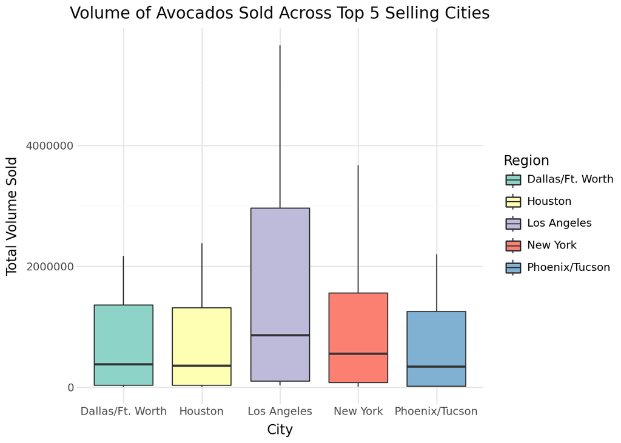

```python
# removing observations with "NaN" as the major geographic region based on city to avoid duplications
avocado_clean_q5 = avocado_clean[(avocado_clean["major_geographic_region"] != "NaN")]

# removing observations that are not at the city-level
avocado_clean_q5 = avocado_clean[(avocado_clean["geography"] != "Total U.S.") & (avocado_clean["geography"] != "California") & (avocado_clean["geography"] != "Great Lakes") & (avocado_clean["geography"] != "Midsouth") & (avocado_clean["geography"] != "Northeast") & (avocado_clean["geography"] != "Plains") & (avocado_clean["geography"] != "Southeast") & (avocado_clean["geography"] != "South Central") & (avocado_clean["geography"] != "West")]

# saving the top cities with highest average total volume
top_cities = (
    avocado_clean_q5[["geography", "total_volume"]]
    .groupby("geography")
    .mean()
    .sort_values("total_volume", ascending = False)
    .head(5)
    .reset_index()
)

# filtering original data to the top cities
avocado_clean_q5 = avocado_clean_q5[avocado_clean_q5["geography"].isin(top_cities["geography"])]

### Plot
(ggplot(avocado_clean_q5,
aes(
    x = "geography",
    y = "total_volume",
    fill = "geography"
))
# boxes
+ geom_boxplot()
+ scale_fill_brewer(type = 'qual', palette='Set3')
# axes and legends
+ labs(title = "Volume of Avocados Sold Across Top 5 Selling Cities", x= "City", y = "Total Volume Sold", fill = "Region")
# background
+ theme_minimal()
)
```

:::

# Pivoting

```python
# Limiting to CA cities observations
avocado_clean_q6 = avocado_clean[(avocado_clean["geography"] == "Los Angeles") | (avocado_clean["geography"] == "San Diego") | (avocado_clean["geography"] == "Sacramento") | (avocado_clean["geography"] == "San Francisco") ]
```

7. The price difference is greatest in San Francisco, where the price difference is 0.72 dollars, on average.

::: {#cell-Exercise 7 .cell execution_count=7}

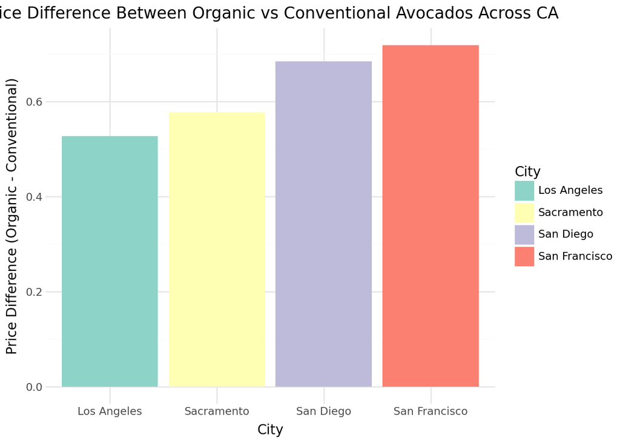

```python
### adjusting the dataframe
# creating side-by-side price columns
avocado_price_diff_pivot = (
    avocado_clean_q6[["geography", "date", "type", "average_price"]]
    .pivot(index=["geography", "date"], columns = "type", values = "average_price")
    .reset_index()
)

# transforming to find price difference
avocado_price_diff_pivot["price_difference"] = avocado_price_diff_pivot["organic"] - avocado_price_diff_pivot["conventional"]

# sorting to see top averages by geography
price_diff_graph = (
    avocado_price_diff_pivot[["geography","price_difference"]]
    .groupby("geography")
    .mean()
    .sort_values("price_difference", ascending = False)
    .reset_index()
)

### Plot
(ggplot(price_diff_graph,
aes(
    x = "geography",
    y = "price_difference",
    fill = "geography"
))
# bars
+ geom_col()
+ scale_fill_brewer(type = 'qual', palette='Set3')
# axes and legends
+ labs(title = "Price Difference Between Organic vs Conventional Avocados Across CA", x= "City", y = "Price Difference (Organic - Conventional)", fill = "City")
# background
+ theme_minimal()
)
```

:::

::: {#cell-Exercise 8 .cell execution_count=8}

[figure not shown]

```python
### Creating a new dataframe
# math to get proportions
small = avocado_clean_q6["small/med sold"] + avocado_clean_q6["small_bags"]
large = avocado_clean_q6["large sold"] + avocado_clean_q6["large_bags"]
xlarge = avocado_clean_q6["extra large sold"] + avocado_clean_q6["xlarge_bags"]
# passing along existing columns
geography = avocado_clean_q6["geography"]
avo_type = avocado_clean_q6["type"]
# declaring dataframe
avocado_CA_sales = pd.DataFrame({"Geography": geography, "Small": small, "Large": large, "XLarge": xlarge, "Type": avo_type})
# melting sizes into Size column
avocado_CA_sales_long_size = avocado_CA_sales.melt(id_vars=["Geography", "Type"], var_name="Size", value_name="Amount")
# sorting
avocado_CA_sales_graph = avocado_CA_sales_long_size.groupby(["Geography", "Type", "Size"]).sum().reset_index()
avocado_CA_sales_graph

### Plot
(ggplot(avocado_CA_sales_graph,
aes(
  x = "Geography",
  y = "Amount",
  fill = "Size"
))
+ geom_bar(stat="identity", position = "fill")
+ facet_wrap("Type")
+ labs(title= "Proportion of Average Hass Avocado Sales by Size", x = "Region of California", y = "Proporition", fill = "Size")
+ theme_minimal()
+ scale_fill_brewer(type = 'qual', palette='Set3')
+ theme(axis_text_x=element_text(angle=45, hjust=1))
)
```

:::

# Using Outside Data

There doesn’t seem to be a strong relationship between housing prices and avocado prices, as seen in the plot. This suggests that we probably shouldn’t claim a causal relationship between the housing market and avocado prices (and the Millennial willingness to pay them).

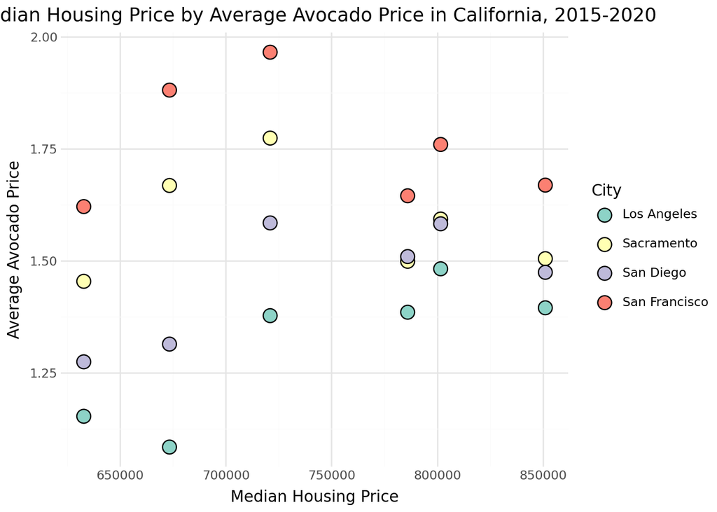

```python
# outside data, values reflect median price
housing = pd.read_excel("C:/Users/lilyg/OneDrive/Documents/MSBA/GSB 544 - Computing and ML/Week 2/MedianPricesofExistingDetachedHomesHistoricalData.xlsx")

### cleaning
# dropping unnecessary columns
columns_to_keep = ["Mon-Yr", "Los Angeles", "Sacramento", "San Diego", "San Francisco"]
housing_clean = housing[columns_to_keep]
# add columns for month and year based on data in "Mon-Yr"
housing_clean['month'] = pd.DatetimeIndex(housing_clean['Mon-Yr']).month
housing_clean['year'] = pd.DatetimeIndex(housing_clean['Mon-Yr']).year
# exclude dates outside timeframe
housing_clean = housing_clean[(housing_clean["year"] > 2014) & (housing_clean["year"] < 2021)]
# melting housing df to match avocado df
housing_clean_long = housing_clean.melt(
    id_vars=["year", "month"],
    value_vars=["Los Angeles", "Sacramento", "San Diego", "San Francisco"],
    var_name="Geography",
    value_name="Median Price"
)

# streamlining avocado df
columns_to_keep_avo = ["geography", "month", "year", "average_price"]
avocado_clean_q7 = avocado_clean_q6[columns_to_keep_avo]

### merging
avo_housing = avocado_clean_q7.merge(housing_clean_long, on = ["month", "year"], suffixes=("_avocado", "_housing"))

# simplifying for visualization -- take mean values of each year
avo_housing_yearly = (
    avo_housing.groupby(["geography", "year"], as_index=False)
      [["average_price", "Median Price"]]
      .mean()
)

### Plot
(ggplot(avo_housing_yearly,
aes(
    x = "Median Price",
    y = "average_price",
    fill = "geography"
))
# bubbles
+ geom_point(size=5)
+ scale_fill_brewer(type = 'qual', palette='Set3')
# labels
+ labs(title = "Median Housing Price by Average Avocado Price in California, 2015-2020", x= "Median Housing Price", y = "Average Avocado Price", fill = "City")
# background
+ theme_minimal()
)
```